# PSYC40940: Customising visualisations

## Themes: `plot`

- `plot.background`
- `plot.margin`
- `plot.title`
- `plot.subtitle`
- `plot.caption`
- `plot.tag`

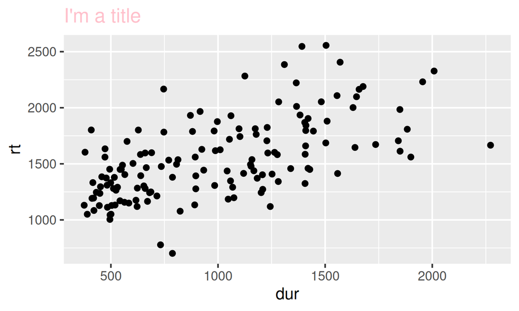

```r
ggplot(d_spellname, aes(y = rt, x = dur)) +
  geom_point() +
  labs(title = "I'm a title") +
  theme(plot.title = element_text(colour = "pink"))
```

## Themes: `plot`

- `plot.background`
- `plot.margin`
- `plot.title`
- `plot.subtitle`
- `plot.caption`
- `plot.tag`

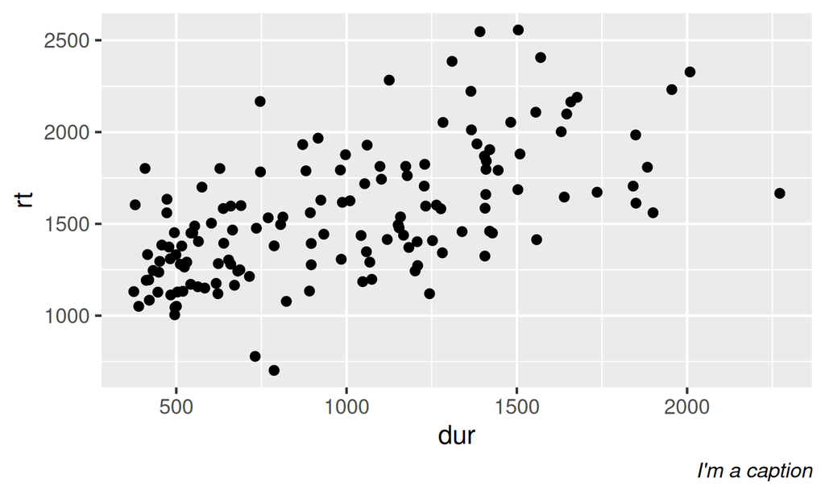

```r
ggplot(d_spellname, aes(y = rt, x = dur)) +
  geom_point() +
  labs(caption = "I'm a caption") +
  theme(plot.caption = element_text(face = "italic"))
```

## Themes: facet strips

- `strip.background`
- `strip.placement`
- `strip.text`

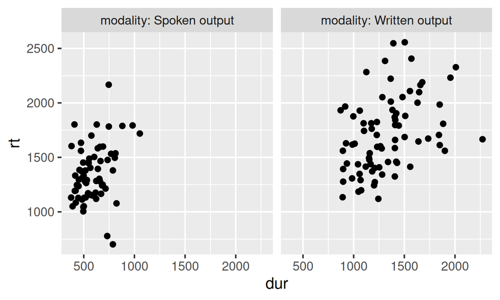

```r
ggplot(d_spellname, aes(y = rt, x = dur)) +
  geom_point() +
  facet_grid(~modality, labeller = label_both) +
  theme()
```

## Themes: `strip.background`

- `strip.background`
- `strip.placement`
- `strip.text`

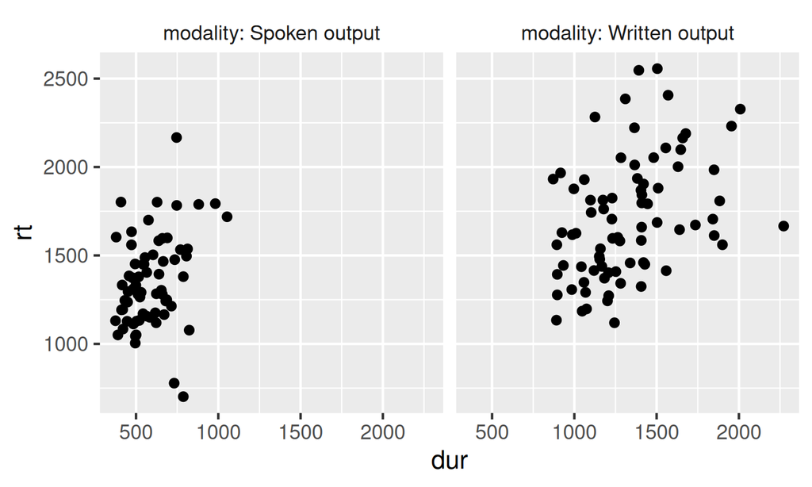

```r
ggplot(d_spellname, aes(y = rt, x = dur)) +
  geom_point() +
  facet_grid(~modality, labeller = label_both) +
  theme(strip.background = element_blank())
```

## Themes: `strip.background`

- `strip.background`
- `strip.placement`
- `strip.text`

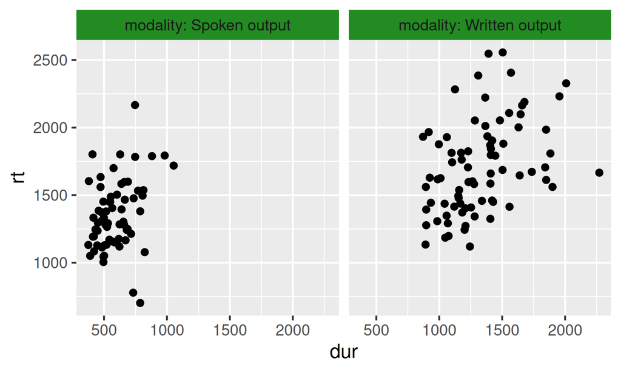

```r
ggplot(d_spellname, aes(y = rt, x = dur)) +
  geom_point() +
  facet_grid(~modality, labeller = label_both) +
  theme(strip.background = element_rect(fill = "forestgreen"))
```

## Themes: `strip.text`

- `strip.background`
- `strip.placement`
- `strip.text`

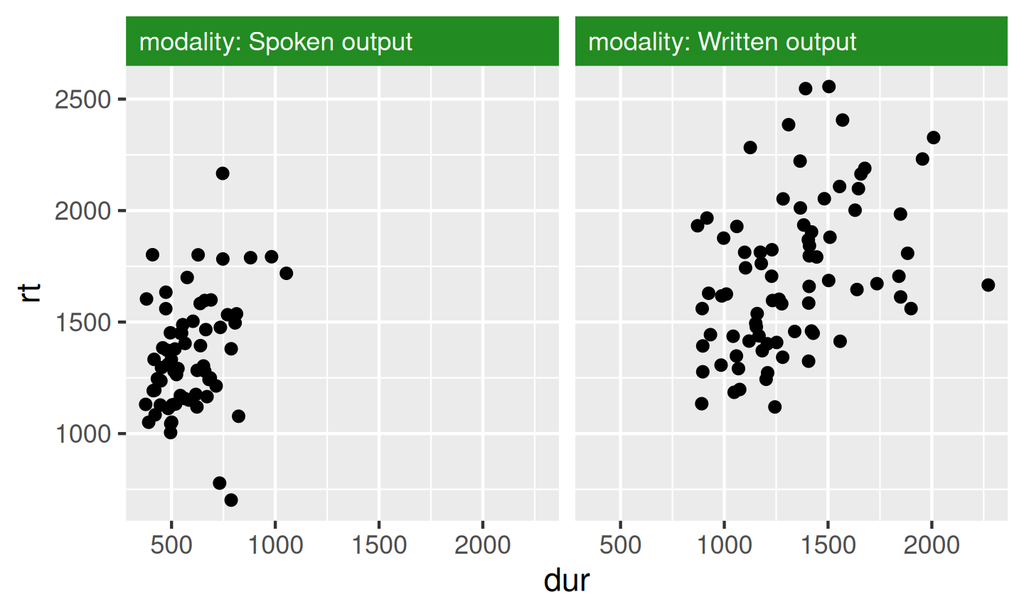

```r
ggplot(d_spellname, aes(y = rt, x = dur)) +
  geom_point() +
  facet_grid(~modality, labeller = label_both)+
  theme(strip.background = element_rect(fill = "forestgreen"),
        strip.text = element_text(colour = "white", hjust = 0))
```

## Themes: `strip.text`

- `strip.background`
- `strip.placement`
- `strip.text`

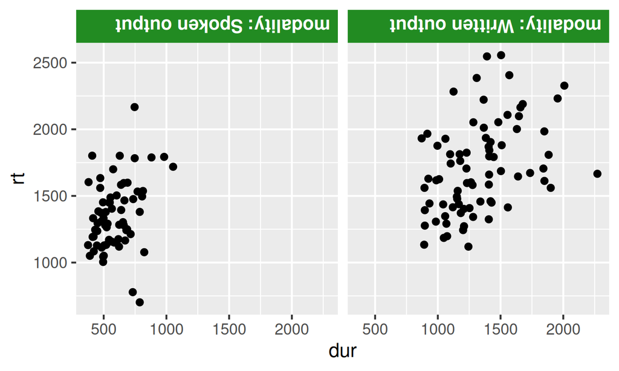

```r
ggplot(d_spellname, aes(y = rt, x = dur)) +
  geom_point() +
  facet_grid(~modality, labeller = label_both) +
  theme(strip.background = element_rect(fill = "forestgreen"),
        strip.text = element_text(colour = "white", hjust = 0,
                                  face = "bold", size = 16,
                                  angle = 180))
```

## Exercise 3: creating your own theme

Complete RMarkdown `3_defining_themes.Rmd`

## Saving your plot

```r
ggsave("name of plot.png", width = 5, height = 5)
```

- `.eps`, `.pdf`, `.svg`, `.wmf`, `.png`, `.jpg`, `.bmp`, `.tiff`
- sizes requires some manual adjustment (or `fig.width` in RMarkdown)
- make sure fonts are not too small / large
- keep the aspect ratio sensible
- or export function in **plots** panel

## Useful resources for data visualisation

- Choosing the right visualisation: [data-to-viz.com](https://www.data-to-viz.com/)
- Rick Scavetta’s course: [datacamp.com](https://learn.datacamp.com/skill-tracks/data-visualization-with-r)
- `ggplot2` [CheatSheet](https://rstudio.com/wp-content/uploads/2015/03/ggplot2-cheatsheet.pdf)
- Most important functions: [ggplot2.tidyverse.org](https://ggplot2.tidyverse.org/reference/)

## Reading

- [Chapters 11, 14, 15, 17 of Wickham (2016)](https://ggplot2-book.org/scales-colour.html)
- [Chapter 3 of Wickham & Grolemund (2016)](https://r4ds.had.co.nz/transform.html)
- [Chapter 4 of Andrews (2021)](https://github.com/mark-andrews/ddsr/releases/download/v22.7.31/chapter_04_visualization.pdf)

## Formative assessment

**Task:** Select a behavioural dataset—-i.e., data related to human behaviour (e.g., psychological experiments, survey responses, reaction times, decision-making patterns, social media behaviour, etc.).

- Create 3-4 visualisations using different techniques (e.g., boxplot, scatterplot, density plot).
- Include brief commentary on:
  - What each visualisation highlights about the data?
  - Why each visualisation was chosen?
  - How each visualisation adheres to principles of effective visualisation (e.g., Tufte’s guidelines)?
  - To what extent the each visualisation may (or may not) obscure the data.
- **Deadline:** 31st October 2025
- **Length:** max 1,000 words

**Feedback focus:**

- Clarity and effectiveness of visualisations.
- Code quality and reproducibility.
- Interpretation and communication of behavioural insights.

## Time permitted!

Let’s rework a figures (e.g. Figure 4) from [van Lieburg et al. (2023)](https://link.springer.com/article/10.1007/s41809-023-00131-5); code and data are [HERE](https://osf.io/x8ejm/).

## References

Andrews, M. (2021). *Doing data science in R: An introduction for Social Scientists*. SAGE Publications Ltd.

Tufte, E. R. (2001). *The visual display of quantitative information* (2nd ed.). Graphics Press.

van Lieburg, R., Sijyeniyo, E., Hartsuiker, R. J., & Bernolet, S. (2023). The development of abstract syntactic representations in beginning L2 learners of Dutch. *Journal of Cultural Cognitive Science*, *7*, 289–309. https://doi.org/10.1007/s41809-023-00131-5

Wickham, H. (2016). *ggplot2: Elegant graphics for data analysis*. Springer.

Wickham, H., & Grolemund, G. (2016). *R for data science: Import, tidy, transform, visualize, and model data*. O’Reilly Media, Inc.